# Notebook

**Research Question:** "For alias generation (judgement ①), how correct is each model in the roster — scored against Opus-as-truth and RxNorm — and how do the models diverge from one another?"

*Judgement ① of 11 · the archetype factual test, now across the full lab roster: correctness vs two truth sources, an N×N divergence map, and a price-aware scorecard. Numbers are computed from the run.*

**Abstract.** Alias generation (judgement ①) is the pipeline's first step — a hallucinated alias propagates into drug-ID and canonicalisation. We test the full roster the way the design specifies: **21 candidate models** across 9+ labs generate aliases for **16 drugs** (k=5, temp 0), each scored for **correctness against two truth sources** — RxNorm (formal) and **Opus-as-judge** (informal aliases + hallucinations RxNorm can't see) — with the judge validated against RxNorm (91% agreement) and an N×N divergence map beside it. **grok-4.5** is the most accurate (95% of aliases judged valid). Crucially, RxNorm and Opus rank the roster differently (rank correlation ρ=0.27); by RxNorm alone the top model would be **qwen3-30b-a3b** — so agreement with the database is a floor, not the verdict. Models that produced no parseable aliases: glm-4.7-flash.

## 1. What this judgement is, and why correctness matters

`get_drug_aliases` asks a model for every name a drug goes by — generic, brand, abbreviation, common misspelling. Those aliases are how the pipeline *finds* the drug in free text, so this is the first LLM judgement and everything downstream inherits its errors. It has a **right answer**, so we measure accuracy, not agreement — and we do it across the whole roster so model choice is grounded.

## 2. Validating the judge before trusting it

Opus-as-judge is a model grading models, so before leaning on it we check it against RxNorm on the subset RxNorm covers: if Opus validates the aliases RxNorm confirms, the judge reproduces objective truth and is trustworthy for the informal aliases (LDN, typos) RxNorm can't reach.

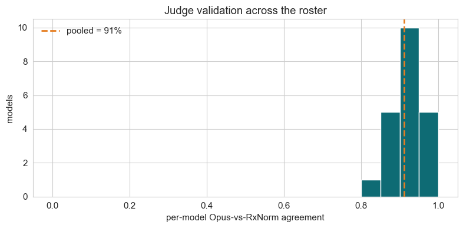

**What this shows:** pooled across the roster, Opus reproduces RxNorm on **91%** of confirmable aliases, and most models sit near that line — the judge is consistently sound, not cherry-picked. Where a model's bar is low, its RxNorm-confirmed set is small and noisy, not evidence the judge failed.

## 3. Correctness scorecard — the verdict

Each model's **Opus-precision** (fraction of its aliases the validated judge calls valid), sorted. This is the accuracy column of the scorecard; the RxNorm floor and the full table follow.

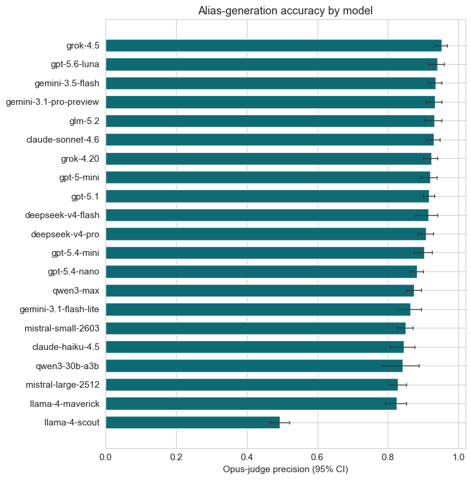

**Per-model correctness**

| model | Opus acc. | RxNorm floor | brand recall | aliases/drug | $/1M in |
| --- | --- | --- | --- | --- | --- |
| grok-4.5 | 95% | 15% | 45% | 19.8 | $2 |
| gpt-5.6-luna | 94% | 19% | 45% | 15.5 | $1 |
| gemini-3.5-flash | 94% | 16% | 42% | 23.1 | $1.5 |
| gemini-3.1-pro-preview | 93% | 19% | 45% | 19.6 | $2 |
| glm-5.2 | 93% | 15% | 27% | 10.4 | $0.906 |
| claude-sonnet-4.6 | 93% | 12% | 42% | 29.0 | $3 |
| grok-4.20 | 92% | 15% | 44% | 21.9 | $1.25 |
| gpt-5-mini | 92% | 20% | 35% | 14.1 | $0.25 |
| gpt-5.1 | 92% | 9% | 45% | 29.1 | $1.25 |
| deepseek-v4-flash | 91% | 20% | 32% | 5.8 | $0.098 |
| deepseek-v4-pro | 91% | 15% | 45% | 12.4 | $0.435 |
| gpt-5.4-mini | 90% | 14% | 48% | 13.2 | $0.75 |
| gpt-5.4-nano | 88% | 7% | 40% | 26.4 | $0.2 |
| qwen3-max | 87% | 10% | 39% | 23.4 | $0.78 |
| gemini-3.1-flash-lite | 86% | 20% | 40% | 19.8 | $0.25 |
| mistral-small-2603 | 85% | 9% | 34% | 25.2 | $0.15 |
| claude-haiku-4.5 | 84% | 17% | 34% | 25.3 | $1 |
| qwen3-30b-a3b | 84% | 31% | 31% | 3.6 | $0.12 |
| mistral-large-2512 | 83% | 11% | 32% | 26.9 | $0.5 |
| llama-4-maverick | 82% | 14% | 24% | 18.2 | $0.2 |
| llama-4-scout | 49% | 8% | 24% | 28.1 | $0.1 |

## 4. Counterintuitive: the objective database ranks the roster differently

Score the roster by RxNorm and by Opus-judge and the orderings disagree. Models can sit high on RxNorm precision yet low on real accuracy (they stick to formal names but still hallucinate), or low on RxNorm yet high on accuracy (they add *correct* informal aliases RxNorm can't confirm). If you ranked models by the objective database — or by how much they agree with each other — you would pick wrong. Only the validated judge tracks truth.

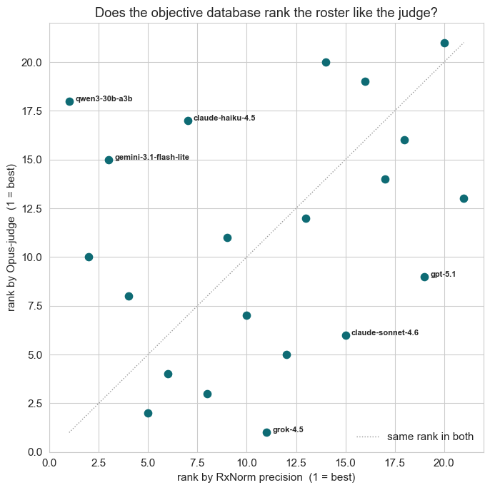

**What this shows:** rank-by-RxNorm against rank-by-Opus (Spearman ρ=0.27). Points off the diagonal are ordered *differently* by the two sources — **qwen3-30b-a3b** moves 17 places between them. A model high-left (good RxNorm rank, poor Opus rank) looks clean in the database but hallucinates; low-right is the reverse — correct informal aliases RxNorm can't confirm. Rank the roster by the database and you order it differently from the validated judge: RxNorm corroborates, it does not rank.

## 5. Comparing the models to each other — divergence map

Correctness says who is *right*; divergence says who *behaves alike*. The matrix is the mean Jaccard of alias sets between every pair of models (1 = identical sets). It clusters the roster into behaviour groups and exposes outliers — but note the caveat: agreeing models can share the same bias, so divergence is a diagnostic, never a correctness verdict.

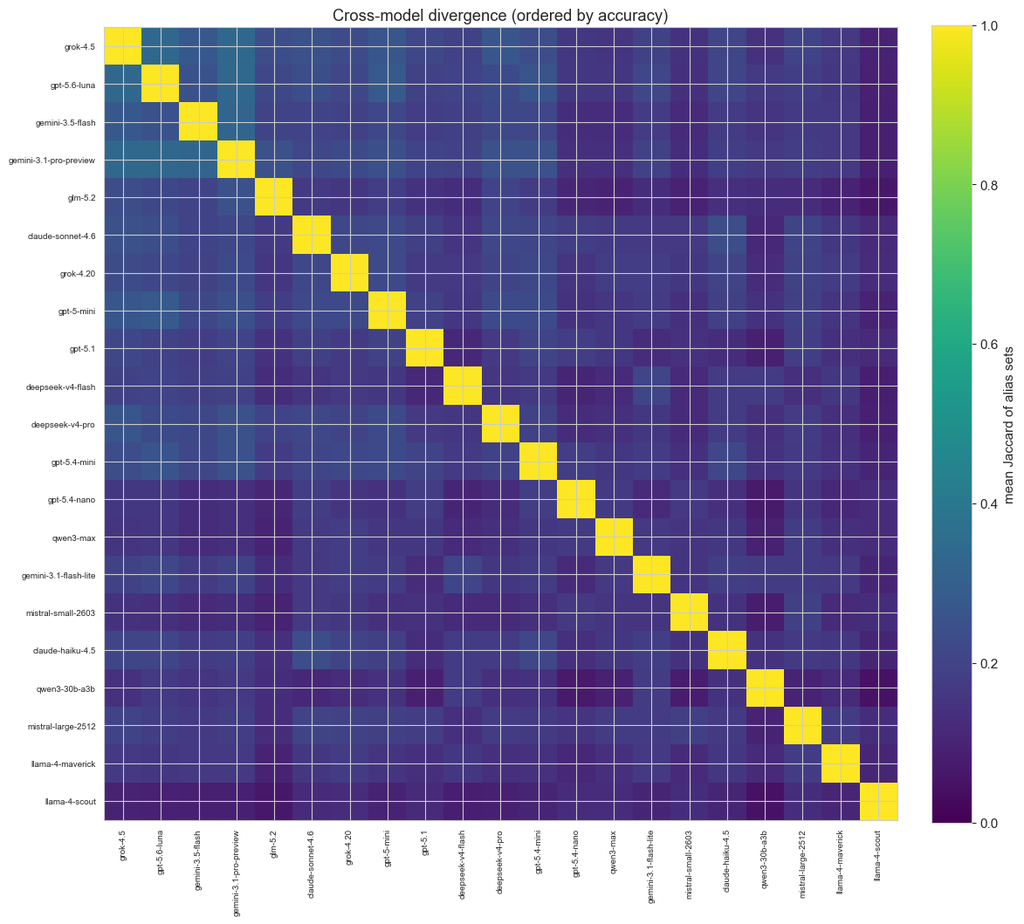

**Most divergent models**

| model | outlier score (1 − mean agreement) | Opus acc. |
| --- | --- | --- |
| llama-4-scout | 0.90 | 49% |
| qwen3-30b-a3b | 0.87 | 84% |
| mistral-small-2603 | 0.86 | 85% |
| gpt-5.4-nano | 0.86 | 88% |
| llama-4-maverick | 0.85 | 82% |
| qwen3-max | 0.85 | 87% |
| glm-5.2 | 0.85 | 93% |
| deepseek-v4-flash | 0.84 | 91% |

**What this shows:** the roster shares a mean **17%** alias overlap. The most *divergent* model is **llama-4-scout** — but divergence alone is not a fault: read it against §3, an outlier that is *also* low-accuracy is a problem; an outlier that stays accurate just formats aliases differently.

## 6. Conclusion & scorecard — accuracy per dollar

The payoff: the full scorecard, and the one number the project turns on — the cheapest model whose accuracy is close to the best (the design's *closest-to-Opus-per-dollar*).

**① alias — full scorecard**

| model | accuracy (Opus) | RxNorm floor | divergence | self-consist (k) | aliases/drug | $/1M in |
| --- | --- | --- | --- | --- | --- | --- |
| grok-4.5 | 95% | 15% | 0.78 | 0.55 | 19.8 | $2 |
| gpt-5.6-luna | 94% | 19% | 0.79 | 0.53 | 15.5 | $1 |
| gemini-3.5-flash | 94% | 16% | 0.81 | NaN | 23.1 | $1.5 |
| gemini-3.1-pro-preview | 93% | 19% | 0.79 | NaN | 19.6 | $2 |
| glm-5.2 | 93% | 15% | 0.85 | NaN | 10.4 | $0.906 |
| claude-sonnet-4.6 | 93% | 12% | 0.81 | 0.66 | 29.0 | $3 |
| grok-4.20 | 92% | 15% | 0.81 | 0.55 | 21.9 | $1.25 |
| gpt-5-mini | 92% | 20% | 0.81 | NaN | 14.1 | $0.25 |
| gpt-5.1 | 92% | 9% | 0.84 | 0.32 | 29.1 | $1.25 |
| deepseek-v4-flash | 91% | 20% | 0.84 | NaN | 5.8 | $0.098 |
| deepseek-v4-pro | 91% | 15% | 0.82 | NaN | 12.4 | $0.435 |
| gpt-5.4-mini | 90% | 14% | 0.81 | 0.36 | 13.2 | $0.75 |
| gpt-5.4-nano | 88% | 7% | 0.86 | 0.25 | 26.4 | $0.2 |
| qwen3-max | 87% | 10% | 0.85 | 0.32 | 23.4 | $0.78 |
| gemini-3.1-flash-lite | 86% | 20% | 0.83 | 0.81 | 19.8 | $0.25 |
| mistral-small-2603 | 85% | 9% | 0.86 | 0.32 | 25.2 | $0.15 |
| claude-haiku-4.5 | 84% | 17% | 0.83 | 1.00 | 25.3 | $1 |
| qwen3-30b-a3b | 84% | 31% | 0.87 | NaN | 3.6 | $0.12 |
| mistral-large-2512 | 83% | 11% | 0.83 | 0.47 | 26.9 | $0.5 |
| llama-4-maverick | 82% | 14% | 0.85 | NaN | 18.2 | $0.2 |
| llama-4-scout | 49% | 8% | 0.90 | 0.25 | 28.1 | $0.1 |

Verdict

- **Most accurate:** grok-4.5 (95% valid). This is the accuracy anchor for the scorecard.

- **Best value (closest to top accuracy per dollar):** **deepseek-v4-flash** — 91% accuracy at $0.098/1M input, within 5 points of the best while cheaper.

- **Judge is sound** (91% vs RxNorm), so these are correctness numbers, not agreement.

- **RxNorm is a floor, divergence is a diagnostic** — neither ranks the roster; the Opus column does.

- **Alias generation is unstable even at temp 0** — mean run-to-run self-Jaccard 0.49, so K=5 is necessary, not optional.

## 7. Research limitations

**Provenance**

| item | value |
| --- | --- |
| run generated (UTC) | 2026-07-18T01:01:46.484050+00:00 |
| judgement | 1_alias_generation |
| candidate models | 22 (21 produced aliases) |
| judge (truth) | anthropic/claude-opus-4.8 |
| truth sources | rxnorm, opus_judge |
| drugs / k | 16 / 5 |
| temperature | 0.0 |
| skill version | research-assistant v2 |

These findings reflect the behaviour of a measurement pipeline and model knowledge, not population-level treatment effects. This is not medical advice.